# MATHS1004 Mathematics for Data Science I

### Interlude: functions

As in other programming languages you can create user-defined functions in Python, using `def`. The syntax is pretty straightforward -- you need to call `def` to define your function, indent the guts of that function (just like for a `for` loop), and make sure to `return` something at the end of your function. Here are two examples:

```python
def square_then_add_19(x):
    # this function squares the number x then adds 19
    y = x**2 + 19
    return y

def special_adding_function(a,b):
    # what does this function do? Make sure you understand.
    my_sum = 0
    for i in range(a,b+1):
        my_sum = my_sum + i
    return my_sum

print(square_then_add_19(3.2))
print(special_adding_function(0,10))
```

```
29.240000000000002
55
```

And you can add as many inputs as you want to both of these functions. (And `return` more outputs too, if you like, using a comma.)

Great! Your turn: write a function `e_to_x_n` which takes in a value `x` and number of terms `n` and computes the series approximation up to term $n$ of $\exp(x)$.

```python
def e_to_x_n(x,n):
    # insert your function here

    e_to_x = 0 # SOLUTION
    for i in range(n+1): # SOLUTION
        e_to_x = e_to_x + x**i/np.math.factorial(i) # SOLUTION
    return e_to_x # SOLUTION
```

Once you've done that, test your function with `x=2` and `n=10` below to make sure it works.

```python
e_to_x_n(2,10)
```

```
7.388994708994708
```

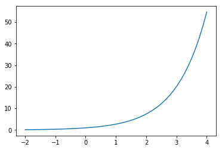

```python
import matplotlib.pyplot as plt

x = np.linspace(-2,4)
y = np.exp(x)
plt.plot(x,y)
plt.show()
```

[figure not shown]

Try to use a loop over the $n$ values to make the plot rather than lots of repeated lines of code. My trick for doing the legends was to use `label="n = "+str(n)` in my plot command; other tricks are possible.

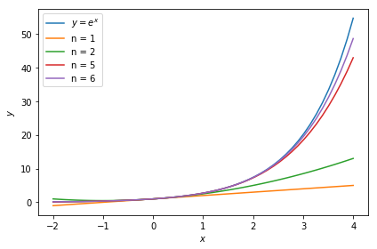

```python
# SOLUTION
x = np.linspace(-2,4)
y = np.exp(x)
plt.plot(x,y,label='$y = e^x$')


for n in [1,2,5,6]:
    y = e_to_x_n(x,n)
    plt.plot(x,y,label="n = "+str(n))
plt.xlabel('$x$')
plt.ylabel('$y$')
plt.legend()
plt.tight_layout()
plt.savefig('TS.png')
plt.show()
```

Further extension problems:

- We'll learn some other Maclaurin series in lectures, or there are plenty on [Wikipedia](https://en.wikipedia.org/wiki/Taylor_series#List_of_Maclaurin_series_of_some_common_functions). Try and write similar functions for these! (The trig functions are a good starting place)
- Fun with recursion and summation: you remember the Golden ratio from *The Da Vinci Code* right? It's the limit of the ratio of consequtive (https://en.wikipedia.org/wiki/Fibonacci_number)[Fibonacci numbers]. Write a function to calculate the $n$th Fibonacci number using a loop, and use it to write a function to approximate the Golden ratio.
- There are other types of loops -- a `while` loop is the most common. How could you rewrite your `e_to_x_n` function to instead of calculating a set number of terms `n`, compute until the difference between consequtive partials sums is less than some error tolerance `tol`? Be warned: this can lead to loops which take a long time to terminate! In which case you might want to explore `break`, or `if`, statements...